# In this file I want to collect the informations that we need in order to predict the consumptions of a builiding

## For first i need to import the external file with the information about consumption, irradiance and temperature

```python
import pandas as pd
import numpy as np
import matplotlib.pyplot as plt
import os

ExternalFilesFolder=r"C:\Users\Alessia\Documents\Primo_anno_en\Building\python4ScientificComputing_Numpy_Pandas_MATPLotLIB\ExternalFiles"
ConsumptionFileName= "consumption_5545.csv"
TemperatureFileName= "Austin_weather_2014.csv"
IrradianceFileName= "irradiance_2014_gen.csv"
path_consumptionFile = os.path.join(ExternalFilesFolder,ConsumptionFileName)
path_TemperatureFile = os.path.join(ExternalFilesFolder,TemperatureFileName)
path_IrradianceFile = os.path.join(ExternalFilesFolder,IrradianceFileName)

# creating a dataframe about consumption
DF_consumption = pd.read_csv(path_consumptionFile,sep=",", index_col=0)

PreviousIndex = DF_consumption.index
NewParsedIndex= pd.to_datetime(PreviousIndex)
DF_consumption.index =NewParsedIndex

# creating a dataframe about temperature in Austin
DF_weather = pd.read_csv(path_TemperatureFile,sep=";",index_col=0)
previousIndex_weather=DF_weather.index
newIndex_weather=pd.to_datetime(previousIndex_weather)
DF_weather.index = newIndex_weather
DF_weather.columns
Series_Temperature = DF_weather["temperature"]
DF_Temperature= DF_weather[["temperature"]]

#creating a dataframe about irradiance
DF_irradianceSource = pd.read_csv(path_IrradianceFile,sep=";",index_col=1)
DF_irradiance=DF_irradianceSource[["gen"]]
DF_irradiance[DF_irradiance["gen"]<0] = 0
previousIndex_irradiance=DF_irradiance.index
newIndex_irradiance=pd.to_datetime(previousIndex_irradiance)
DF_irradiance.index = newIndex_irradiance
```

### Now, I create a dataframe with all these information

```python
DF_joined = DF_consumption.join([DF_Temperature,DF_irradiance])

# we should "clean" the table ,replacing the "none" with zero value
DF_joined_cleaned = DF_joined.dropna()
DF_joined_cleaned_copy=DF_joined_cleaned.copy()

#consider a new dataframe related only to some days of august
DF_joined_cleaned_chosenDates=DF_joined_cleaned_copy["2014-08-01 ":"2014-08-04 "]
DF_joined_cleaned_chosenDates.dropna()
```

|  | air conditioner_5545 | temperature | gen |
| --- | --- | --- | --- |
| 2014-08-01 00:00:00 | 825.183333 | 90.71 | 0.000000 |
| 2014-08-01 01:00:00 | 677.516667 | 88.08 | 0.000000 |
| 2014-08-01 02:00:00 | 535.883333 | 85.73 | 0.000000 |
| 2014-08-01 03:00:00 | 474.450000 | 83.20 | 0.000000 |
| 2014-08-01 04:00:00 | 228.800000 | 80.37 | 0.000000 |
| 2014-08-01 05:00:00 | 0.000000 | 79.05 | 0.000000 |
| 2014-08-01 06:00:00 | 0.000000 | 76.74 | 0.000000 |
| 2014-08-01 07:00:00 | 0.000000 | 76.22 | 0.197417 |
| 2014-08-01 08:00:00 | 0.000000 | 75.20 | 0.596800 |
| 2014-08-01 09:00:00 | 0.000000 | 75.20 | 0.900500 |
| 2014-08-01 10:00:00 | 0.000000 | 74.44 | 1.645517 |
| 2014-08-01 11:00:00 | 0.000000 | 73.20 | 2.859850 |
| 2014-08-01 12:00:00 | 0.000000 | 72.51 | 3.501433 |
| 2014-08-01 13:00:00 | 0.000000 | 73.24 | 4.165450 |
| 2014-08-01 14:00:00 | 324.500000 | 74.34 | 3.941200 |
| 2014-08-01 15:00:00 | 475.033333 | 77.24 | 3.983717 |
| 2014-08-01 16:00:00 | 1383.266667 | 80.07 | 3.609200 |
| 2014-08-01 17:00:00 | 2098.800000 | 83.07 | 2.265450 |
| 2014-08-01 18:00:00 | 2013.216667 | 86.12 | 1.621800 |
| 2014-08-01 19:00:00 | 2371.566667 | 87.69 | 0.397733 |
| 2014-08-01 20:00:00 | 2008.666667 | 88.88 | 0.003750 |
| 2014-08-01 21:00:00 | 1979.216667 | 88.98 | 0.000000 |
| 2014-08-01 22:00:00 | 1443.733333 | 88.47 | 0.000000 |
| 2014-08-01 23:00:00 | 744.566667 | 87.46 | 0.000000 |
| 2014-08-02 00:00:00 | 494.516667 | 84.88 | 0.000000 |
| 2014-08-02 01:00:00 | 259.200000 | 82.34 | 0.000000 |
| 2014-08-02 02:00:00 | 222.250000 | 79.93 | 0.000000 |
| 2014-08-02 03:00:00 | 557.583333 | 77.79 | 0.000000 |
| 2014-08-02 04:00:00 | 322.383333 | 75.88 | 0.000000 |
| 2014-08-02 05:00:00 | 0.000000 | 74.63 | 0.000000 |
| ... | ... | ... | ... |
| 2014-08-03 18:00:00 | 2099.600000 | 86.59 | 1.533267 |
| 2014-08-03 19:00:00 | 2217.266667 | 89.07 | 0.506267 |
| 2014-08-03 20:00:00 | 2422.866667 | 90.95 | 0.000000 |
| 2014-08-03 21:00:00 | 2167.966667 | 91.51 | 0.000000 |
| 2014-08-03 22:00:00 | 1952.816667 | 92.44 | 0.000000 |
| 2014-08-03 23:00:00 | 1291.250000 | 90.10 | 0.000000 |
| 2014-08-04 00:00:00 | 683.683333 | 89.92 | 0.000000 |
| 2014-08-04 01:00:00 | 659.333333 | 87.62 | 0.000000 |
| 2014-08-04 02:00:00 | 473.800000 | 84.74 | 0.000000 |
| 2014-08-04 03:00:00 | 431.833333 | 81.15 | 0.000000 |
| 2014-08-04 04:00:00 | 80.933333 | 79.93 | 0.000000 |
| 2014-08-04 05:00:00 | 0.000000 | 78.96 | 0.000000 |
| 2014-08-04 06:00:00 | 0.000000 | 77.62 | 0.000000 |
| 2014-08-04 07:00:00 | 0.000000 | 75.69 | 0.174033 |
| 2014-08-04 08:00:00 | 0.000000 | 75.39 | 0.603583 |
| 2014-08-04 09:00:00 | 0.000000 | 74.53 | 1.076283 |
| 2014-08-04 10:00:00 | 0.000000 | 74.09 | 2.224750 |
| 2014-08-04 11:00:00 | 0.000000 | 72.88 | 2.959217 |
| 2014-08-04 12:00:00 | 79.683333 | 72.68 | 3.457833 |
| 2014-08-04 13:00:00 | 438.883333 | 75.25 | 3.934567 |
| 2014-08-04 14:00:00 | 1282.966667 | 79.00 | 3.580767 |
| 2014-08-04 15:00:00 | 1242.550000 | 83.20 | 3.067300 |
| 2014-08-04 16:00:00 | 1554.166667 | 84.73 | 3.205950 |
| 2014-08-04 17:00:00 | 2508.633333 | 87.53 | 2.858383 |
| 2014-08-04 18:00:00 | 2515.400000 | 89.54 | 1.673900 |
| 2014-08-04 19:00:00 | 2476.633333 | 91.63 | 0.503317 |
| 2014-08-04 20:00:00 | 2175.700000 | 90.99 | 0.000000 |
| 2014-08-04 21:00:00 | 2376.400000 | 92.31 | 0.000000 |
| 2014-08-04 22:00:00 | 1829.900000 | 92.32 | 0.000000 |
| 2014-08-04 23:00:00 | 1374.133333 | 89.43 | 0.000000 |

96 rows × 3 columns

## We can plot the datas related at this period of time,after normalizing them

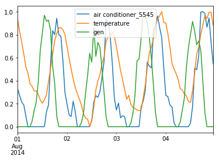

```python
#plot after normalizing the dates
DF_joined_cleaned_chosenDates_min=DF_joined_cleaned_chosenDates.min()
DF_joined_cleaned_chosenDates_max=DF_joined_cleaned_chosenDates.max()
DF_joined_cleaned_chosenDates_normalized= (DF_joined_cleaned_chosenDates-DF_joined_cleaned_chosenDates_min)/(DF_joined_cleaned_chosenDates_max-DF_joined_cleaned_chosenDates_min)
plt.figure()
DF_joined_cleaned_chosenDates_normalized.plot()
plt.show()
```

## As we can see from the plot, the datas peaks don't corrispond so we have to "shift" the Austin temperature in order to consider the time zone

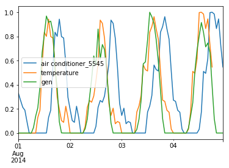

```python
DF_joined_cleaned_chosenDates["temperature"]=DF_joined_cleaned_chosenDates.shift(-5)
DF_joined_cleaned_chosenDates.dropna()

DF_joined_cleaned_chosenDates_min=DF_joined_cleaned_chosenDates.min()
DF_joined_cleaned_chosenDates_max=DF_joined_cleaned_chosenDates.max()
DF_joined_cleaned_chosenDates_norm=(DF_joined_cleaned_chosenDates-DF_joined_cleaned_chosenDates_min)/(DF_joined_cleaned_chosenDates_max-DF_joined_cleaned_chosenDates_min)
plt.figure()
DF_joined_cleaned_chosenDates_norm.plot()
plt.show()
```

## Now, we can reconstruct my dataframe by applying time zone to the whole dataset

```python
DF_joined=DF_consumption.join([DF_Temperature,DF_irradiance])
DF_mod=DF_joined.copy()
DF_mod["temperature"]=DF_mod["temperature"].shift(-5)
DF_mod.dropna(inplace=True)   # It is the same as writing it like this: DF_mod=DF_mod.dropna()
```

## In order to consider the time lags we will need to include all of these columns with lags (shifts)

## Instead of use shift comand for every line of temperature that we need :

### DF_mod["Temperature -1h"]= DF_mod["temperature"].shift(1)

### DF_mod["Temperature -2h"]= DF_mod["temperature"].shift(2)

### DF_mod["Temperature -3h"]= DF_mod["temperature"].shift(3)

### DF_mod["Temperature -4h"]= DF_mod["temperature"].shift(4)

### DF_mod["Temperature -5h"]= DF_mod["temperature"].shift(5)

### DF_mod["Temperature -6h"]= DF_mod["temperature"].shift(6)

## we can use a faster metod: we can write a function with cycle for that write a new column in the dataframe for every operation of shift made.

### We introduce first the initial and final values of interval of time lag that we need and apply the funtion to our case

```python
lag_start=1
lag_end=6
lag_interval=1

column_name="temperature"
df=DF_mod



def lag_feature(df,column_name,lag_start,lag_end,lag_interval):
    for i in range(lag_start,lag_end+1,lag_interval):
        new_column_name=column_name+"-"+str(i)+"hr"
        print new_column_name
        df[new_column_name]=df[column_name].shift(i)
        df.dropna(inplace=True)
    return df

DF_mod=lag_feature(DF_mod,"temperature",1,6,1)
```

```
temperature-1hr
temperature-2hr
temperature-3hr
temperature-4hr
temperature-5hr
temperature-6hr
```

## We can made the same also for irradiance for 3 to 6 hours and consumption in last 24 hours. But we want first rename these columns

```python
DF_mod=DF_mod.rename(columns={"air conditioner_5545":"AC_Consumption","gen":"irradiance"} )
#another way was:DF_mod.columns =["AC_consumption","temperature","irradiance"]

DF_mod=lag_feature(DF_mod,"AC_Consumption",1,24,1)
DF_mod=lag_feature(DF_mod,"irradiance",3,6,1)
```

```
AC_Consumption-1hr
AC_Consumption-2hr
AC_Consumption-3hr
AC_Consumption-4hr
AC_Consumption-5hr
AC_Consumption-6hr
AC_Consumption-7hr
AC_Consumption-8hr
AC_Consumption-9hr
AC_Consumption-10hr
AC_Consumption-11hr
AC_Consumption-12hr
AC_Consumption-13hr
AC_Consumption-14hr
AC_Consumption-15hr
AC_Consumption-16hr
AC_Consumption-17hr
AC_Consumption-18hr
AC_Consumption-19hr
AC_Consumption-20hr
AC_Consumption-21hr
AC_Consumption-22hr
AC_Consumption-23hr
AC_Consumption-24hr
irradiance-3hr
irradiance-4hr
irradiance-5hr
irradiance-6hr
```

## At then end, we add seasonality parameter(time related):add a column for hour, two columns for "continuos"hours,another one for day,month and day of week

```python
DF_mod["hour"]=DF_mod.index.hour
DF_mod["hour"].head()
DF_mod["sin_hour"]=np.sin(DF_mod.index.hour*2*np.pi/24)
DF_mod["cos_hour"]=np.cos(DF_mod.index.hour*2*np.pi/24)

DF_mod["day_of_week"]=DF_mod.index.dayofweek
DF_mod[["hour","sin_hour","cos_hour","day_of_week"]].head(24)

DF_mod["month"]=DF_mod.index.month

DF_mod["week_of_year"]=DF_mod.index.week
```

## In this way we can, easily, create a function in order to know if it's a weekend day or not and create a new column with this information

```python
def WeekendDetector(day):
    if (day==5 or day==6):
        weekendLabel=1
    else:
        weekendLabel=0
    return weekendLabel

DF_mod["weekend"]=DF_mod["day_of_week"].apply(WeekendDetector)
```

## At the end we can create another function to konw if an hour it's a working hour or not,so if there are people inside

```python
def DayDetector(hour):
    if (hour<19 and hour>=9):
        DayLabel=1
    else:
        DayLabel=0
    return DayLabel

DF_mod["workingTime"]=DF_mod["hour"].apply(DayDetector)
```

```python
DF_mod.head()
```

|  | AC_Consumption | temperature | irradiance | temperature-1hr | temperature-2hr | temperature-3hr | temperature-4hr | temperature-5hr | temperature-6hr | AC_Consumption-1hr | ... | irradiance-5hr | irradiance-6hr | hour | sin_hour | cos_hour | day_of_week | month | week_of_year | weekend | workingTime |
| --- | --- | --- | --- | --- | --- | --- | --- | --- | --- | --- | --- | --- | --- | --- | --- | --- | --- | --- | --- | --- | --- |
| 2014-01-15 09:00:00 | 0.0 | 39.31 | 2.191083 | 39.24 | 40.81 | 40.74 | 42.79 | 44.15 | 47.02 | 0.0 | ... | 0.000000 | 0.0000 | 9 | 7.071068e-01 | -0.707107 | 2 | 1 | 3 | 0 | 1 |
| 2014-01-15 10:00:00 | 0.0 | 43.73 | 3.120000 | 39.31 | 39.24 | 40.81 | 40.74 | 42.79 | 44.15 | 0.0 | ... | 0.000000 | 0.0000 | 10 | 5.000000e-01 | -0.866025 | 2 | 1 | 3 | 0 | 1 |
| 2014-01-15 11:00:00 | 0.0 | 49.51 | 3.865200 | 43.73 | 39.31 | 39.24 | 40.81 | 40.74 | 42.79 | 0.0 | ... | 0.000000 | 0.0000 | 11 | 2.588190e-01 | -0.965926 | 2 | 1 | 3 | 0 | 1 |
| 2014-01-15 12:00:00 | 0.0 | 53.34 | 4.267967 | 49.51 | 43.73 | 39.31 | 39.24 | 40.81 | 40.74 | 0.0 | ... | 0.078900 | 0.0000 | 12 | 1.224647e-16 | -1.000000 | 2 | 1 | 3 | 0 | 1 |
| 2014-01-15 13:00:00 | 0.0 | 57.37 | 4.310133 | 53.34 | 49.51 | 43.73 | 39.31 | 39.24 | 40.81 | 0.0 | ... | 0.862767 | 0.0789 | 13 | -2.588190e-01 | -0.965926 | 2 | 1 | 3 | 0 | 1 |

5 rows × 45 columns